# Handling Tower Transactions

We can create our tower shop using *UITowerPurchaseButton*. The shop supplies *Towers* to players, provided they have the gold to buy them.

Let’s create a new scene. We are going to use a *Panel* node as root. This will allow us to create a nice-looking interface. Rename it as *UITowerShop* and save the scene as `res://UI/UITowerShop/UITowerShop.tscn`.

Add a *Label* as the first child of the shop to communicate to players they can purchase *Towers* using this panel. In the *Label > Text* property, say something like *Purchase New Towers*.

Add a *HBoxContainer* to contain *UITowerPurchaseButton*. Add a *UITowerPurchaseButton* as a child of the *HBoxContainer*. We can provide information about the tower to players by using *UITowerPurchaseButton > Hint > Tooltip*.

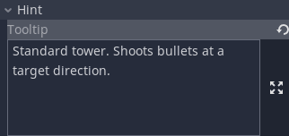

Now when players hover on a tower, they can have a sense of what they are buying.

Let’s improve the design. Toggle on the *Use Grid Snap* with `Shift` + `G`. In the Layout menu, select the *Center Bottom* option. This is where our shop should anchor itself as players scale the window.

Design the elements taking into account a small margin from the panel’s edge. This is how we’ve designed it.

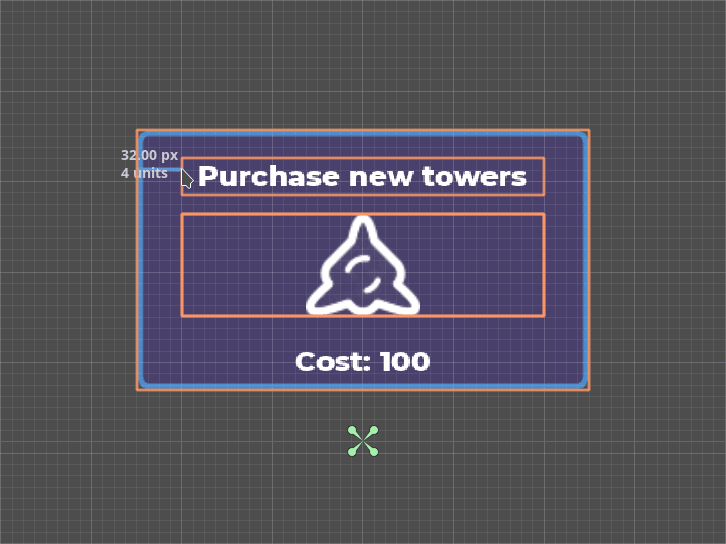

Attach a script to the root node and save it in the same folder as the scene.

In the script, the first thing to do is to create a signal to notify other classes that the player has purchased a tower.

We also need a reference to the buttons.

The shop’s main responsibility is to handle transactions so we need to access the player’s gold. The shop itself isn’t initially aware of the existence of a player, but later we’ll have a class that satisfies this dependency.

```
class_name UITowerShop
extends Panel

signal tower_purchased(tower)

onready var _buttons: Array = $HBoxContainer.get_children()

var player: Player
```

The buttons should notify the shop every time the player prompts the acquisition of a new tower using their `tower_purchased` signal. The shop doesn’t listen to this signal yet, so let’s subscribe to this signal on every button.

```
func _ready() -> void:
    for button in _buttons:
        button.connect("tower_purchased", self, "_on_TowerPurchaseButton_tower_purchased")
```

Let’s create this `_on_TowerPurchaseButton_tower_purchased()` callback.

The first thing we do is instance the tower we receive through the signal. The shop manages *every* tower transaction, including when players sell towers. Every time the shop creates new towers, it subscribes itself to their `sold` signal so it can use its `_on_Tower_sold()` callback.

[figure not shown]

[figure not shown]

```
func _on_TowerPurchaseButton_tower_purchased(tower_scene: PackedScene) -> void:
    var tower: Tower = tower_scene.instance()

    tower.connect("sold", self, "_on_Tower_sold")
    emit_signal("tower_purchased", tower)
```

Now, let’s handle when players sell towers.

Whenever you need to create a signal callback of a node you create in run time, you can use the editor instead. This will ensure the callback signature matches the signal. Add an instance of a *Tower* as a child of the *UITowerShop*. Then, use the signal connection interface to create the callback method. Don’t forget to remove the *Tower* instance after this setup.

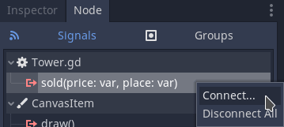

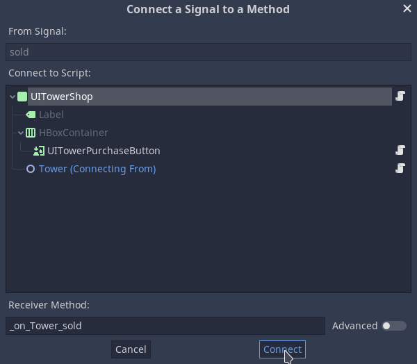

In the `_on_Tower_sold()` we take the `price` argument and uses it to increase the `player.gold`. And that’s it.

```
func _on_Tower_sold(price: int, _position: Vector2) -> void:
    player.gold += price
```

Notice that until now, the shop doesn’t charge the player. This is because the player didn’t manage to place their brand new *Tower*.

We’ve seen in our *TowerPlacer* that players don’t always place towers in free cells and the tower disappears. We won’t charge the player in this case until the *TowerPlacer* emits its `tower_placed` signal.

The shop shouldn’t be aware of the existence of a *TowerPlacer*. But that doesn’t prevent it from having a callback prepared beforehand. We’ll see later how the *Game* node will handle this interaction.

Anyway, let’s create an `_on_TowerPlacer_tower_placed()` callback so the shop can charge the player.

```
func _on_TowerPlacer_tower_placed(tower: Tower) -> void:
    player.gold -= tower.cost
```

We don’t have any mechanism that prevents players from purchasing towers even if they don’t have enough gold. To solve this, we disable every button that has its `tower_cost` greater than `player.gold`. We need to do this every time the player’s gold changes. We’ll create a callback for this.

```
func _on_Player_gold_changed(gold_amount: int) -> void:
    for button in _buttons:
        if button.tower_cost > gold_amount:
            button.disabled = true
        else:
            button.disabled = false
```

We have the callback, but we don’t have the signal connection yet. We encapsulate the `player` variable into a `set_player()` method. In this setter method, we perform the connection so we set the connection up as soon as the shop receives a player to work with.

```
var player: Player setget set_player

func set_player(new_player: Player) -> void:
    player = new_player
    player.connect("gold_changed", self, "_on_Player_gold_changed")
```

The complete code for our *UITowerShop* should look like this:

`UITowerShop.gd`

```
class_name UITowerShop
extends Panel

signal tower_purchased(tower)

onready var _buttons: Array = $HBoxContainer.get_children()

var player: Player setget set_player


func _ready() -> void:
    for button in _buttons:
        button.connect("tower_purchased", self, "_on_TowerPurchaseButton_tower_purchased")


func set_player(new_player: Player) -> void:
    player = new_player
    player.connect("gold_changed", self, "_on_Player_gold_changed")


func _on_TowerPurchaseButton_tower_purchased(tower_scene: PackedScene) -> void:
    var tower: Tower = tower_scene.instance()

    tower.connect("sold", self, "_on_Tower_sold")
    emit_signal("tower_purchased", tower)


func _on_TowerPlacer_tower_placed(tower: Tower) -> void:
    player.gold -= tower.cost


func _on_Tower_sold(price: int, _position: Vector2) -> void:
    player.gold += price


func _on_Player_gold_changed(gold_amount: int) -> void:
    for button in _buttons:
        if button.tower_cost > gold_amount:
            button.disabled = true
        else:
            button.disabled = false
```

## Testing the shop

To test how the *UITowerShop* works, let’s setup a testing environment. Create a new scene with a basic node as root. Add an instance of the *UITowerShop* as its child.

Our shop needs a *Player* and a *TowerPlacer* to work as intended so add them as children.

Connect the *TowerPlacer*’s `tower_placed` signal to the shop’s `_on_TowerPlacer_tower_placed()` callback.

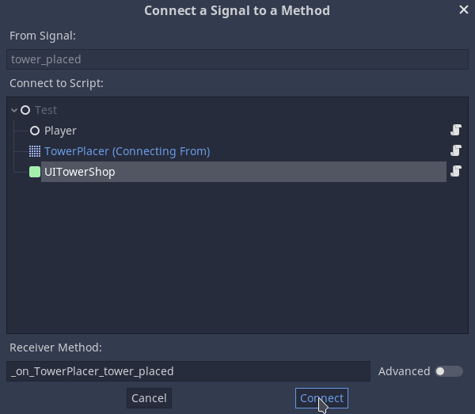

The shop is the one responsible for generating the towers. Connect its `tower_purchased` signal to the *TowerPlacer* `add_new_tower()` method so they can communicate.

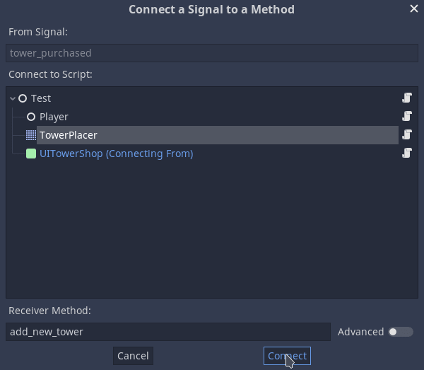

We create a built-in script for the *Test* scene to set up the initialization of the components of our scene. The shop needs a player to work with and the *TowerPlacer* needs us to tell which cells are available to place towers on.

We make a bidirectional loop to feed the *TowerPlacer* with some cells so the left portion of the window has placeable cells.

```
extends Node


func _ready() -> void:
    $UITowerShop.player = $Player

    for i in 15:
        for j in 20:
            var cell := Vector2(i, j)
            $TowerPlacer.set_cell_placeable(cell)
```

As we only access each node once, we don’t need to store them into reference variables.

We want to test three things:

- The *TowerShop* communication with the *TowerPlacer*
- The *TowerShop* handling of *Player*’s gold
- The *TowerShop* management of *TowerPurchaseButtons*

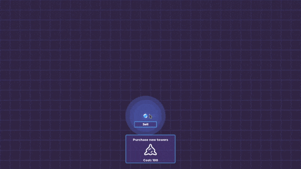

*Perfect!*

Delete this *Test* scene to keep the project clean.